# Mini Oktoberfest Analysis

Ranji Raj

2021-04-15

In this mini analysis we work with a dataset provided by the [Statistics Office Munich](https://www.opengov-muenchen.de/dataset/oktoberfest/) about the Oktoberfest. More specifically, the dataset includes annual Oktoberfest duration statistics, total visitors, daily visitors, beer prices, beer consumption, grilled chicken (*“Hendl”*) prices and grilled chicken consumption.

Your task is to **fill in the blanks!**

## Packages and data

```r
library(tidyverse)
of <- read_csv("oktoberfest-en.csv")
of
```

```
## # A tibble: 35 x 8
##     year duration_in_days visitors_total visitors_daily beer_price_per_l
##    <dbl>            <dbl>          <dbl>          <dbl>            <dbl>
##  1  1985               16            7.1            444             3.2
##  2  1986               16            6.7            419             3.3
##  3  1987               16            6.5            406             3.37
##  4  1988               16            5.7            356             3.45
##  5  1989               16            6.2            388             3.6
##  6  1990               16            6.7            419             3.77
##  7  1991               16            6.4            400             4.21
##  8  1992               16            5.9            369             4.42
##  9  1993               16            6.5            406             4.71
## 10  1994               16            6.6            413             4.89
## # ... with 25 more rows, and 3 more variables: beer_consumption_hl <dbl>,
## #   hendl_price <dbl>, hendl_consumption <dbl>
```

The dataset contains information on 35 years of the Oktoberfest. For each year, 7 statistics are available.

Let’s find out for which years exactly data are available.

```r
of %>% pull(year)
```

```
##  [1] 1985 1986 1987 1988 1989 1990 1991 1992 1993 1994 1995 1996 1997 1998 1999
## [16] 2000 2001 2002 2003 2004 2005 2006 2007 2008 2009 2010 2011 2012 2013 2014
## [31] 2015 2016 2017 2018 2019
```

In this analysis we’ll focus on the change of the following measurements over time:

- `beer_price_per_l`: the beer price per liter in Euro
- `beer_consumption_hl`: the beer consumption in hectoliter (1 hl = 100 l)
- `hendl_price`: the price of a “Hendl” (grilled chicken) in Euro
- `hendl_consumption`: the number of Hendls eaten during the Oktoberfest

## Beer consumption over time

```r
of %>%
  arrange(desc(year)) %>%
  select(year, beer_consumption_hl)
```

[output not shown]

A line plot gives us an even better overview of beer consumption over time:

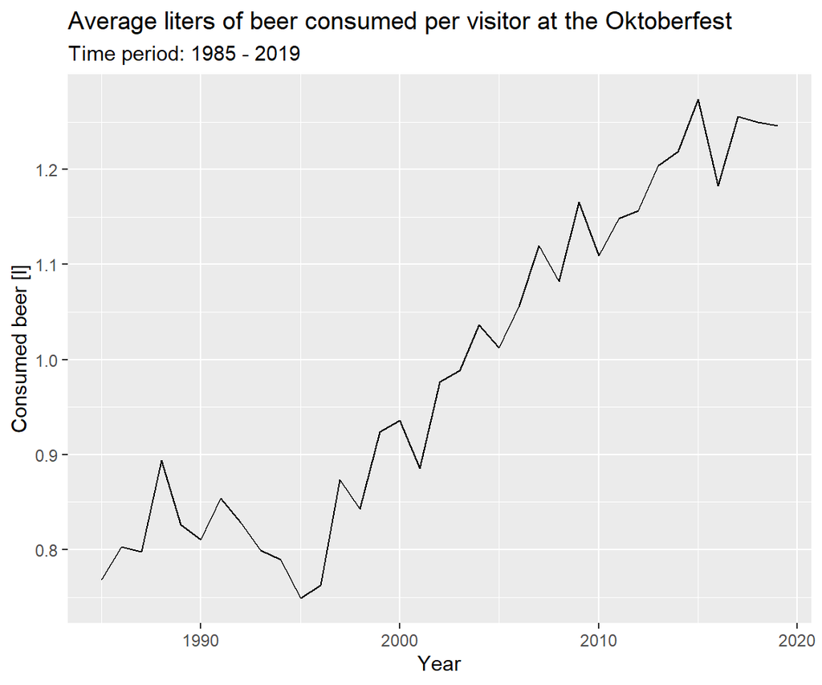

```r
of %>%
  mutate(beer_per_visitor_l = (100 * beer_consumption_hl) /
           (visitors_total * 1000000)) %>%
  ggplot(data = ., mapping = aes(x = year, y = beer_per_visitor_l)) +
  geom_line() +
  labs(
    title = "Average liters of beer consumed per visitor at the Oktoberfest",
    subtitle = "Time period: 1985 - 2019",
    x = "Year",
    y = "Consumed beer [l]"
  )
```